# Your Digest for Tuesday, Oct 17, 2023 11:59 PM

# PRES syndrome

AKA Posterior leukoencephalopathy syndrome (PLS), reversible PLS (RPLS), 'brain capillary leak syndrome'

#2020GM-JUL/Q11  
Defined by clinical and radidological features:

- **Clinical** : headache with visual symptoms, confusion and seizures.
  - *Headache*: constant, nonlocalized.
  - *Altered* conciousness: from mild drowsiness to coma
  - *Visual* *perception abnormalities*: Hemianopia, visual neglect, Auras, cortical blindness[[#^0c0f52]] and denial of blindness (Anton syndrome)
  - *Seizures*: Generalized tonic clonic.
- **Imaging** : MRI shows *vasogenic oedema* in the subcortical white matter of the posterior cerebral hemispheres. Diffusion weighted MRI is required to distinguish this radiologically from stroke.
- Occurs in the background of hypertensive crisis, preeclampsia or with cytotoxic immunosuppressive drugs + many others. (TTP, HUS, vasculitides)
- **Management**:
  - Mainstay is management of the hypertension.
  - For preeclampsia / eclampsia, manage that.
  - Stop causative agents.
- **Prognosis**: usually resolves within 2 weeks but permanent sequelae can occur if there is intercurrent infarction or haemorrhage.

> [!INFO] Cortical blindness  
> Cortical blindness (CB) is defined as *loss of vision without any ophthalmological causes and with normal pupillary light reflexes due to bilateral lesions of the striate cortex in the occipital lobes*.  
> Anton syndrome: patients with cortical blindness are blind but they do not know it. They will deny blindness leading to confabulations. They will say the 'room is dark'.  
> [Source](https://www.ncbi.nlm.nih.gov/books/NBK560626/)

^0c0f52

# Superior orbital fissure syndrome

#2020GM-JUL/Q11

> The superior orbital fissure syndrome (SOFS) is **a complex of impaired function of the cranial nerves (III, IV, V, and VI) that enter the orbit through the superior orbital fissure (SOF)**. Three major precipitating factors for SOFS are trauma, tumor, and inflammation.  
> [Source](https://www.ncbi.nlm.nih.gov/pmc/articles/PMC3700164/)

Features:

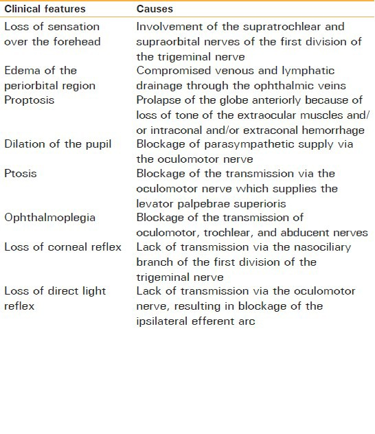

[figure not shown]

[figure not shown]

[output not shown]

#2020GM-JUL/Q03

> [!INFO] Timelines for STEMI management  
> [Source](https://www.ahajournals.org/doi/full/10.1161/01.cir.0000134791.68010.fa) <- AHA guidelines; see Hypothesis highlights.
> - PCI is a valid option if the patient present **within 12 hours of symptom *ONSET***.
>   - If time since onset is > 3 hours, primary PCI is generally preferred.
> - Once the patient does present to healthcare services:
> - Target *door to balloon time* for STEMI PCI **90 minutes**. (lowered from previous recommendation of 120 minutes).
> - If the patient is to receive fibronolysis rather than PCI (for whatever reason):
> - Target *door to needle time* should be < 30 minutes.
> - Transfer to a PCI capable center (instead of primary PCI):
>   - Is an acceptable alternative if door to balloon time will still be < 90 minutes since presentation to the *transferring* hospital.
>   - In such a case, if the door to balloon time exceeds the door to needle time by >= 60 minutes, fibrinolysis is preferred.
> - Ideally, the '90 minutes' is measured since first contact with healcare services. If this is EMS, then *EMS to balloon time should be < 90 minutes*. If first presentation is to hospital, then door to balloon time should be < 90 minutes.

## Selecting a reperfusion strategy

> [!INFO]  
> The higher the risk of bleeding for the partient, the more PCI is preferred over thrombolysis.

## Management of **complicated** STEMI

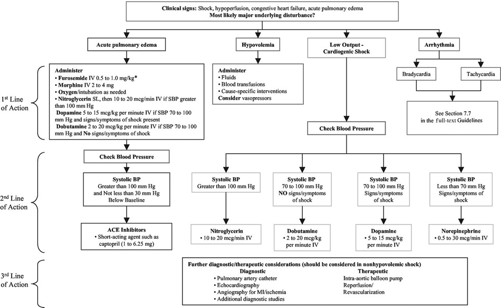

[Source](https://www.ahajournals.org/doi/full/10.1161/01.cir.0000134791.68010.fa#d1e5323)

> [!INFO] Definition of failed thrombolysis  
> Definition of failed thrombolysis : peristent chest pain, failed ST segment resolution, persistent hypotension, ongoing arrhythmias -- all indicate failed thrombolysis. - From CCPMCQDiscussion

[[2020-NOV-GeneralMedicine#STEMI management]]

[output not shown]

Haemodynamically unstable -> **thrombolysis** (if thrombolysis is contraindicated, embolectomy)

#2020GM-JUL/Q11

# 📑Optic neuritis

> [!TIP] 📑Young woman presenting with blurred vision in one eye -> **Optic neuritis!**  
> 📑*Impairment of visual **acuity*** over *hours to days* *with occular pain (worsening with eye movement) and loss of **colour** vision* out of proportion to loss of acuity.  
> **Pathogenesis**: Commonest is 📑inflamatory demyelinition of the optic nerve.  
> **Management**: IV methylprednisilone. Even without treatment vision usually improves upto 20/40.

# 📑Hypertensive emergency

#2020GM-JUL/Q35

-📑 Hypertensive emergency = hypertension (usually SBP > 180 / DPB > 120) **with associated end organ damage**.  
#2020GM-JUL/Q35  
Use the following targets for **MOST hypertensive emergencies**. (Exceptions are given below)

- by 10-20% (mnemonic: 1/5th) in the *first hour*.
- 5 - 15% over the next (mnemonic 1/10th) *23 hours*.  
  #2020GM-JUL/Q35  
  Even for acute heart failure, improvement is often achieved with only a 10-15% reduction in blood pressure. [Source](https://www.uptodate.com/contents/evaluation-and-treatment-of-hypertensive-emergencies-in-adults)

For pre-eclampsia, MAP should be lowered by no more than 25% over 2 hours. This will probably result in higher than normal pressure. Aggressive lowering to normal BP may reduce placental perfusion.  
1st line drugs: IV labetalol, hydralazine and nifedipine.  
Hypertensive encephalpathy : 1st hour 10-20% reduction of BP and no more than 25% reduction over 24 hours.  
| Labetalol | Non selective beta and alpha adrenergic blocker. | Should not be used in failure, bradycardia, heart block, asthma, COPD. |  
| Hydralazine | Arteriolar dilator; **NOT** a preferred drug in hypertensive emergency. | Should be given with a beta blocker to prevent reflex tachycardia. |

> [!INFO] In management of heart failure with hypertension:  
> Drugs that increase cardiac work (eg, **hydralazine**) or acutely decrease cardiac contractility (eg, **labetalol** or other beta blocker) should be **avoided** .

> Cardiac glycosides *reversibly* *inhibit* the **sodium-potassium-ATPase**, causing an increase in intracellular sodium and a decrease in intracellular potassium.
1. Heart failure - *inhibition of Na/K ATPase* -> increased intra-myocyte sodium -> decreased Na calcium exchange -> reduced secretion of calcium -> *increased intracellular calcium* -> contractility increased.  
   In patients with HF, [digoxin](https://www.uptodate.com/contents/digoxin-drug-information?search=digoxin&topicRef=122165&source=see_link) also *inhibits sympathetic outflow* and *augments parasympathetic tone*.
- Increased parasympathetic tone to the SA node and AV node -> (via 📑 *hypersensitization of carotid sinus baroreceptors,* central stimulation, *increased vagal output*, and possible potentiation of the effect of acetylcholine on the sinoatrial [SA] node) -> **📑slowing the firing of the SA node and prolonging conduction at the atrioventricular (AV) node.**  
  Antiarrhythmic - slows conduction through the *AV* node, increases vagal tone. This property is used to slow the ventricular rate in patients with persistent AF.

📑**Avoid** in acute coronary syndrome

> [!INFO] **Benign effects on the ECG**:  
> [Source](https://litfl.com/digoxin-effect-ecg-library/)  
> #2020GM-JUL/Q02  
> These effects occur **at therapeutic doses**
> - Downsloping ST depression - 'salvador dali' or 'reverse tick' appearance.
> - Biphasic T waves.(negative deflection followed by positive) (or even flattened of inverted T waves)
> - The preceding two changes are used by decreased in the atrial and ventricular refractory periods and alterations in ventricular repolorization.
> - **Shortening** of QT interval
> - Mild prolongation of the PR interval due to increased vagal tone to the AV node.

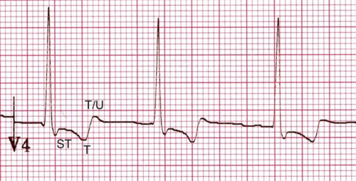

## Digoxin toxicity

### Factors predisposing to toxicity

- Has a narrow therapeutic window
- Especially **hypokalemia** or hypomagnesemia can potentiate toxicity.
- Hypercalcemia can increase risk of toxicity. Hypocalcemia can nullify digoxin effects. -> maintain normal electrolyte levels.
- *Renal dysfunction increases digoxin levels* and often precipitate toxicity!
- Drug interactions
  - Amiodarone and verapamil displace digoxin from tissue binding sites and reduce renal excretion

### Acute toxicity

*Acute toxicity* is uncommon: Effects are

- Hyperkalemia (inhibition of Na/K ATPase),
- confusion and weakness is **COMMON**
- hypomagnesemia,
- hypoxia will predispose to exagerrated action of digoxin. - Correct before administration.

### Chronic toxicity

- Hypokalemia
- Symptoms - GI: N/V/D Dizziness, *CNS may be prominent :* Confusion, Delirium
- Bradycardia
- *Supraventricular tachycardias* (?due to increase automaticity) with or without heart block
- Ventriular tachycardia
- Ventricular ectopics (premature ventricular complexes)
- Hyperkalemia (inhibition of Na/K Pump)
- 📑Side effect: Gynaecomastia

> [!WARNING] Common effects of digoxin toxicity on the ECG  
> Other common dysrhythmias associated with digoxin toxicity include:
> - Frequent PVCs (the most common abnormality), including ventricular bigeminy and trigeminy
> - Sinus bradycardia
> - Slow Atrial Fibrillation
> - Any type of AV block (1st degree, 2nd degree & 3rd degree)
> - Regularised AF = AF with complete heart block and a junctional or ventricular escape rhythm
> - Ventricular tachycardia, including polymorphic and bidirectional VT
> - [Source](https://litfl.com/digoxin-toxicity-ecg-library/)
- Apparently magnesium chloride can be used in digoxin toxicity. (Rang&Dale)